# Module1

Lotte Pohl

6/10/2024

## First graph: Kaliningrad Bridge Problem

```r
# Load the igraph package
if(!require(dplyr)) install.packages("dplyr"); library(dplyr)
if(!require(igraph)) install.packages("igraph"); library(igraph)
```

```r
# list available functions for the igraph package:
# ls("package:igraph")
```

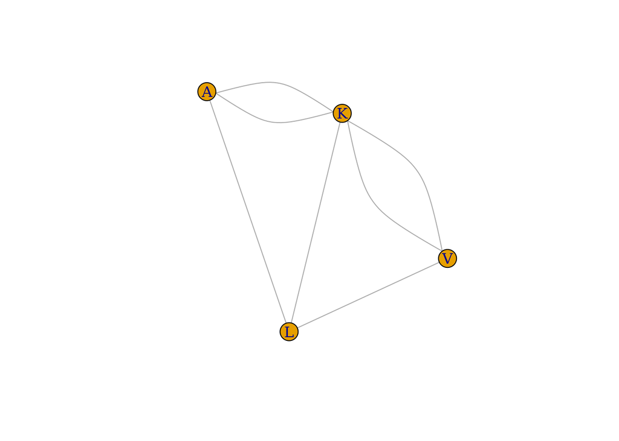

```r
# Define the vertices
vertices <- c("L", "V", "K", "A")

# Define the edges (pairs of neighborhoods connected by a bridge)
edges <- c("L", "A",
           "L", "K",
           "L", "V",
           "V", "K",
           "A", "K",
           "K", "A",
           "K", "V")

# Create the graph from the edge list
G <- graph(edges, directed=FALSE)

# Add names to the vertices
V(G)$name <- vertices

# Plot the graph
plot(G)
```

```r
print(G) #identical to 'G'
```

```
## IGRAPH 4d603b9 UN-- 4 7 --
## + attr: name (v/c)
## + edges from 4d603b9 (vertex names):
## [1] L--V L--K L--A K--A V--K V--K K--A
```

```r
# Write your answer above this line
```

## Practice: Simple and multiple graphs

```r
## For demonstration purposes, we'll create a simple graph for seven islands in the Mediterranean Sea.

# Creating a data frame for Mediterranean islands with a single column for names.
mediterranean_islands <- data.frame(
  name = c(
    "Sicily", "Sardinia", "Cyprus", "Crete", "Corsica", "Mallorca", "Menorca"
  )
)

# Creating a data frame for the simple relations between the islands.
# Each pair of islands is connected by a single edge, with no island connected to itself.
relations <- data.frame(
  from = c(
    "Sicily", "Sicily", "Sardinia",
    "Cyprus", "Crete", "Corsica",
    "Corsica", "Mallorca", "Mallorca"
  ),
  to = c(
    "Sardinia", "Crete", "Corsica",
    "Crete", "Cyprus", "Mallorca",
    "Sicily", "Menorca", "Sardinia"
  )
)

# Using the igraph package to create a simple graph object from the relations data frame.
# This graph is undirected, meaning the relationships do not have a specified direction, reflecting the simple nature of the graph.
# The vertices are defined by the mediterranean_islands data frame.
g_med_isl <- graph_from_data_frame(relations, directed = FALSE, vertices = mediterranean_islands)

# Complete the code #
is_simple(g_med_isl)
```

```
## [1] FALSE
```

```r
any_multiple(g_med_isl)
```

```
## [1] TRUE
```

```r
count_multiple(g_med_isl)
```

```
## [1] 1 1 1 2 2 1 1 1 1
```

```r
any_loop(g_med_isl)
```

```
## [1] FALSE
```

```r
print(g_med_isl)
```

```
## IGRAPH 1fd4efe UN-- 7 9 --
## + attr: name (v/c)
## + edges from 1fd4efe (vertex names):
## [1] Sicily  --Sardinia Sicily  --Crete    Sardinia--Corsica  Cyprus  --Crete
## [5] Cyprus  --Crete    Corsica --Mallorca Sicily  --Corsica  Mallorca--Menorca
## [9] Sardinia--Mallorca
```

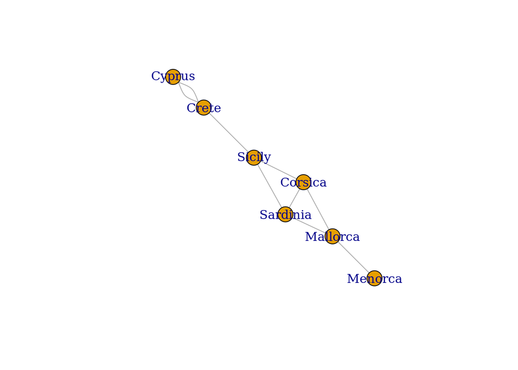

```r
plot(g_med_isl)
```

```r
# Write your answer above this line
```

## Practice: Creating and manipulating graphs

```r
# Load the igraph library
library(igraph)

# Create the graph using an edge list
G2 <- igraph::graph(
  edges = c(1, 2,
            2, 3,
            1, 4,
            2, 5,
            3, 5),
  n = 5,
  directed = FALSE
)

# Look into structure
print(G2)
```

```
## IGRAPH 1b34dec U--- 5 5 --
## + edges from 1b34dec:
## [1] 1--2 2--3 1--4 2--5 3--5
```

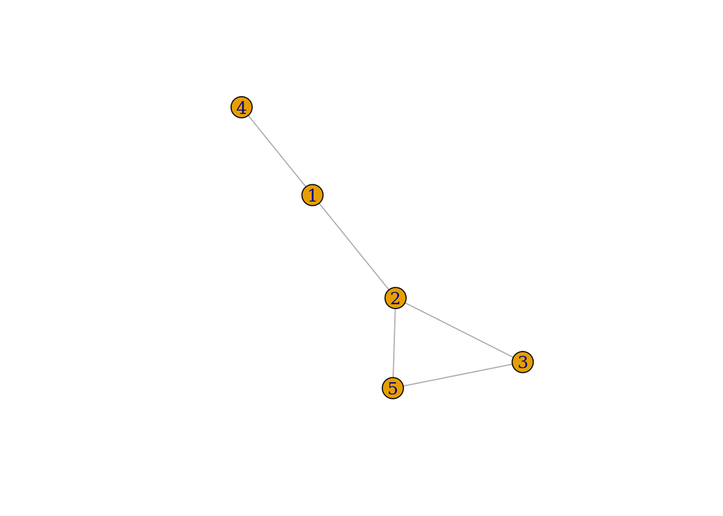

```r
# Visualise
plot(G2)
```

## Practice: The humpback whale migration Network

Humpback whales, as majestic migrators, traverse vast oceanic distances annually, visiting feeding and breeding grounds. These migration patterns are crucial for their survival and have significant ecological impacts. Understanding these patterns is vital for conservation efforts and ecological studies.

> I chose to recreate Fig 3. from Rizzo and Schulte, 2009 (https://doi.org/10.1017/S0025315409000332)

### Create Data Frames

Begin by creating two data frames in R. The first, whale_locations, will list various oceanic regions frequented by whales. The second, migration_routes, will detail the routes whales take from one region to another.

```r
whale_locations <- data.frame(
  location = c("Bering Sea", "Japan", "Hawaii", "Alaska", "California", "Mexico", "Dominican Republic",
               "Maine", "Nova Scotia", "Newfoundland", "Greenland", "Iceland")
)

migration_routes <- data.frame(
  from = c("Bering Sea", "Hawaii", "Hawaii", "Hawaii", "California", "Dominican Republic", "Dominican Republic", "Dominican Republic", "Dominican Republic", "Dominican Republic", "Alaska", "California"),
  to = c("Japan", "Alaska", "California", "Mexico", "Mexico", "Maine", "Newfoundland", "Greenland", "Iceland", "Nova Scotia", "California", "Alaska")

)
```

### Construct the Graph

Use the ‘igraph’ package to build a directed graph from these data frames. In this graph, each region is a vertex, and each migration route is a directed edge.

```r
G3 <- igraph::graph_from_data_frame(migration_routes, directed = T, vertices = whale_locations)
```

### Visualize the Graph

Analyze the graph by printing its structure and plotting it. This will help in identifying key migratory paths and regions that are central to whale migration.

```r
print(G3)
```

```
## IGRAPH 405eea3 DN-- 12 12 --
## + attr: name (v/c)
## + edges from 405eea3 (vertex names):
##  [1] Bering Sea        ->Japan        Hawaii            ->Alaska
##  [3] Hawaii            ->California   Hawaii            ->Mexico
##  [5] California        ->Mexico       Dominican Republic->Maine
##  [7] Dominican Republic->Newfoundland Dominican Republic->Greenland
##  [9] Dominican Republic->Iceland      Dominican Republic->Nova Scotia
## [11] Alaska            ->California   California        ->Alaska
```

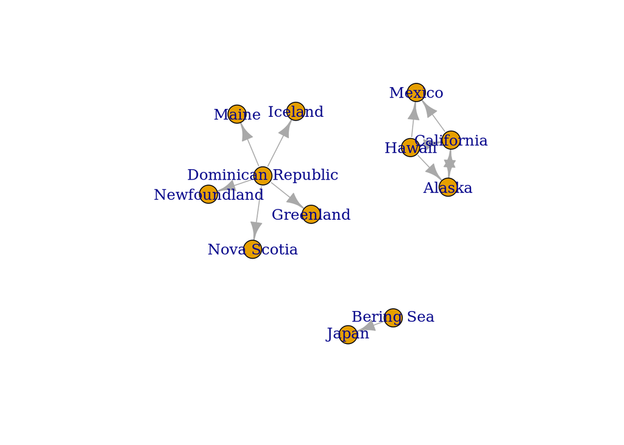

```r
plot(G3) # looks nicer in this example
```

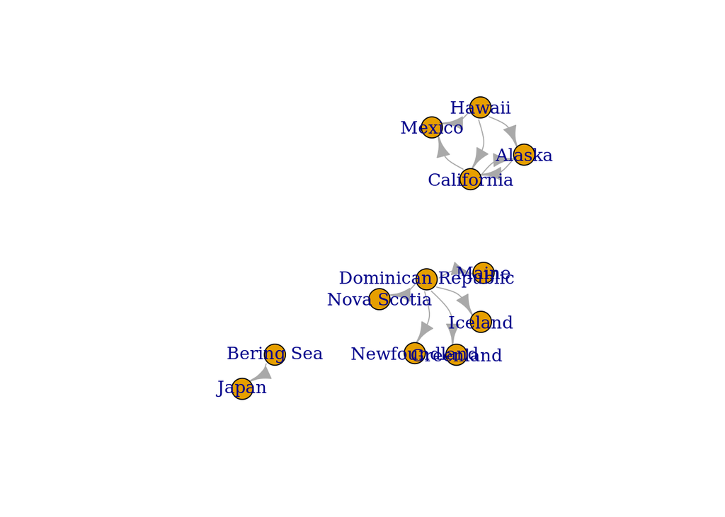

```r
plot(G3, layout = layout_with_gem, edge.curved = TRUE)
```

### Inspect the graph

```r
is.simple(G3)
```

```
## [1] TRUE
```

```r
any_multiple(G3)
```

```
## [1] FALSE
```

```r
which_multiple(G3)
```

```
##  [1] FALSE FALSE FALSE FALSE FALSE FALSE FALSE FALSE FALSE FALSE FALSE FALSE
```

```r
count_multiple(G3)
```

```
##  [1] 1 1 1 1 1 1 1 1 1 1 1 1
```

```r
any_loop(G3)
```

```
## [1] FALSE
```

```r
which_loop(G3)
```

```
##  [1] FALSE FALSE FALSE FALSE FALSE FALSE FALSE FALSE FALSE FALSE FALSE FALSE
```

## Practice: The strength of migration

```r
wt_migration_routes <-
  migration_routes %>%
    dplyr::mutate(weight = stats::runif(n = nrow(migration_routes), min = 0, max = 1) %>% round(digits = 2))
```

### Crafting the weigthed migration network

Once you have examined the ‘wt_migration_routes’ data frame, proceed to construct the weighted graph ‘G4’. To do this, employ the graph_from_data_frame() function, similar to the previous approach.

```r
G4 <- igraph::graph_from_data_frame(wt_migration_routes, directed = T, vertices = whale_locations)
```

### Practical Tips

To view the weight values associated with each edge, use the command `E(G4)$weight`. This will list the weights, helping you understand the intensity of each migratory route. To see the names of the vertices, execute `V(G4)$name`. This displays the names of all locations in your graph, facilitating easier identification of the nodes.

```r
E(G4)$weight
```

```
##  [1] 0.78 0.67 0.63 0.64 0.06 0.42 0.19 0.87 0.52 0.96 0.15 0.56
```

```r
V(G4)$name
```

```
##  [1] "Bering Sea"         "Japan"              "Hawaii"
##  [4] "Alaska"             "California"         "Mexico"
##  [7] "Dominican Republic" "Maine"              "Nova Scotia"
## [10] "Newfoundland"       "Greenland"          "Iceland"
```

### Visualise G4

```r
print(G4)
```

```
## IGRAPH d3acd6d DNW- 12 12 --
## + attr: name (v/c), weight (e/n)
## + edges from d3acd6d (vertex names):
##  [1] Bering Sea        ->Japan        Hawaii            ->Alaska
##  [3] Hawaii            ->California   Hawaii            ->Mexico
##  [5] California        ->Mexico       Dominican Republic->Maine
##  [7] Dominican Republic->Newfoundland Dominican Republic->Greenland
##  [9] Dominican Republic->Iceland      Dominican Republic->Nova Scotia
## [11] Alaska            ->California   California        ->Alaska
```

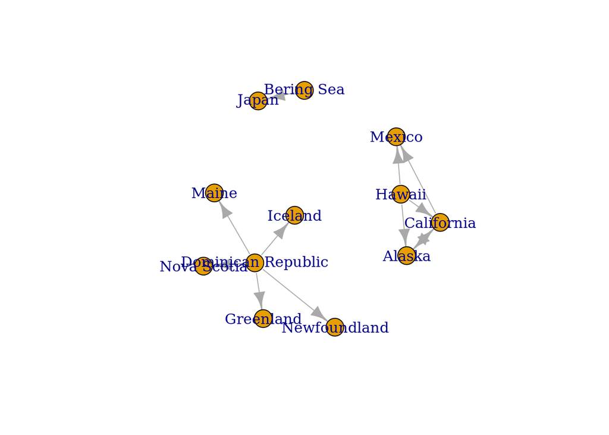

```r
plot(G4) # looks nicer in this example
```

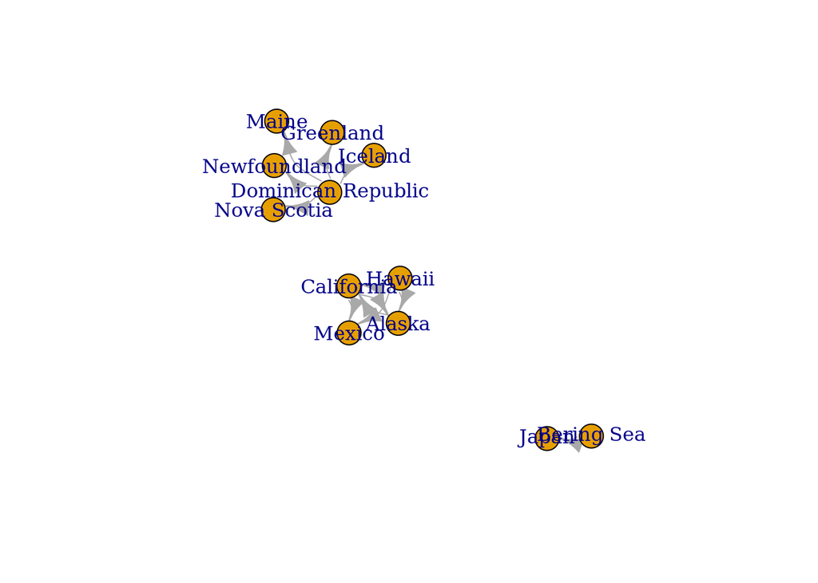

```r
plot(G4, layout = layout_with_gem, edge.curved = TRUE)
```

### Inspect G4

```r
is.simple(G4)
```

```
## [1] TRUE
```

```r
any_multiple(G4)
```

```
## [1] FALSE
```

```r
which_multiple(G4)
```

```
##  [1] FALSE FALSE FALSE FALSE FALSE FALSE FALSE FALSE FALSE FALSE FALSE FALSE
```

```r
count_multiple(G4)
```

```
##  [1] 1 1 1 1 1 1 1 1 1 1 1 1
```

```r
any_loop(G4)
```

```
## [1] FALSE
```

```r
which_loop(G4)
```

```
##  [1] FALSE FALSE FALSE FALSE FALSE FALSE FALSE FALSE FALSE FALSE FALSE FALSE
```